# Untitled2-Copy1

Title: Predicting Online Purchase Intent: A Comprehensive Study of Consumer Behavior

Introduction Online consumer behavior is influenced by numerous factors, including website usage patterns, session attributes, and user characteristics. This dataset provides tracking data on user interactions with an online store, with the primary goal of predicting whether a user makes a purchase during a session.

Dataset Description The dataset contains detailed information on user sessions, including both behavioral and contextual features. It consists of 18 variables and 12330 counts, describing user activity, website metrics, and session outcomes, specifically:

Administrative: The number of pages related to website administration visited by the user. Administrative_Duration: The time spent on administrative pages during the session (in seconds). Informational: The number of informational pages visited. Informational_Duration: The time spent on informational pages (in seconds). ProductRelated: The number of pages related to product browsing. ProductRelated_Duration: The time spent on product-related pages (in seconds). BounceRates: The percentage of visitors who leave the site after viewing only one page. ExitRates: The average percentage of visitors who exit from a specific page. PageValues: The monetary value of a page, calculated based on the number of conversions generated. SpecialDay: A value ranging from 0 to 1, indicating the closeness of the session date to a special day (e.g., Mother’s Day). Categorical Variables:

Month: The month during which the session occurred. OperatingSystems: The operating system used by the user. Browser: The browser used during the session. Region: The geographic region of the user. TrafficType: The source of traffic for the session (e.g., direct, referral, ad campaigns). VisitorType: Indicates whether the user is a new or returning visitor. Weekend: A logical variable indicating whether the session occurred on a weekend (TRUE/FALSE). Revenue (Response Variable): A binary outcome indicating whether a purchase was made during the session (1 = TRUE, 0 = FALSE).

Summary of Data Characteristics

The dataset includes both numerical and categorical variables, with Revenue as the binary response variable. Behavioral metrics like BounceRates and ExitRates can provide insights into user engagement and session quality. Contextual variables like SpecialDay and Month reflect temporal aspects that may influence purchasing decisions.

# IMPORT LIBRARIES

```python
import pandas as pd
import numpy as np
import matplotlib.pyplot as plt
import seaborn as sns
from sklearn.model_selection import train_test_split
from sklearn.linear_model import LogisticRegression, Lasso, Ridge
from sklearn.metrics import confusion_matrix, accuracy_score, precision_score, recall_score, f1_score, roc_curve, auc
from sklearn.preprocessing import StandardScaler, OneHotEncoder
from sklearn.compose import ColumnTransformer
from sklearn.pipeline import Pipeline
```

# LOAD DATASETS

```python
# Load the dataset
data = pd.read_csv(r"C:\Users\manna\OneDrive\Desktop\online_shoppers_intention.csv")

# Summarize the data
print(data.describe())
print(data.info())

# Check for missing values
missing_summary = data.isna().sum()
print(missing_summary)
```

```
       Administrative  Administrative_Duration  Informational  \
count    12330.000000             12330.000000   12330.000000
mean         2.315166                80.818611       0.503569
std          3.321784               176.779107       1.270156
min          0.000000                 0.000000       0.000000
25%          0.000000                 0.000000       0.000000
50%          1.000000                 7.500000       0.000000
75%          4.000000                93.256250       0.000000
max         27.000000              3398.750000      24.000000

       Informational_Duration  ProductRelated  ProductRelated_Duration  \
count            12330.000000    12330.000000             12330.000000
mean                34.472398       31.731468              1194.746220
std                140.749294       44.475503              1913.669288
min                  0.000000        0.000000                 0.000000
25%                  0.000000        7.000000               184.137500
50%                  0.000000       18.000000               598.936905
75%                  0.000000       38.000000              1464.157214
max               2549.375000      705.000000             63973.522230

        BounceRates     ExitRates    PageValues    SpecialDay  \
count  12330.000000  12330.000000  12330.000000  12330.000000
mean       0.022191      0.043073      5.889258      0.061427
std        0.048488      0.048597     18.568437      0.198917
min        0.000000      0.000000      0.000000      0.000000
25%        0.000000      0.014286      0.000000      0.000000
50%        0.003112      0.025156      0.000000      0.000000
75%        0.016813      0.050000      0.000000      0.000000
max        0.200000      0.200000    361.763742      1.000000

       OperatingSystems       Browser        Region   TrafficType
count      12330.000000  12330.000000  12330.000000  12330.000000
mean           2.124006      2.357097      3.147364      4.069586
std            0.911325      1.717277      2.401591      4.025169
min            1.000000      1.000000      1.000000      1.000000
25%            2.000000      2.000000      1.000000      2.000000
50%            2.000000      2.000000      3.000000      2.000000
75%            3.000000      2.000000      4.000000      4.000000
max            8.000000     13.000000      9.000000     20.000000
<class 'pandas.core.frame.DataFrame'>
```

[output cut: 29 more lines]

```
ProductRelated             0
ProductRelated_Duration    0
BounceRates                0
ExitRates                  0
PageValues                 0
SpecialDay                 0
Month                      0
OperatingSystems           0
Browser                    0
Region                     0
TrafficType                0
VisitorType                0
Weekend                    0
Revenue                    0
dtype: int64
```

# EXPLORATORY DATA ANALYSIS (EDA)

# Visualize Class Imbalance

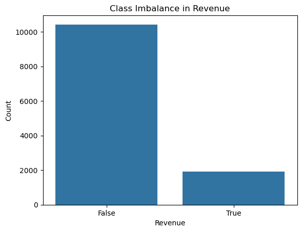

```python
# Visualize class imbalance
sns.countplot(x='Revenue', data=data)
plt.title("Class Imbalance in Revenue")
plt.xlabel("Revenue")
plt.ylabel("Count")
plt.show()
```

The analysis of the target variable, Revenue, reveals a significant class imbalance. The majority of data points are categorized as False (Revenue = 0, indicating no purchase), while only a small fraction are True (Revenue = 1, indicating a purchase).This imbalance highlights that most users did not complete a purchase during their sessions.

```python
# Convert 'Revenue' boolean values to 1 (True) and 0 (False)
data['Revenue'] = data['Revenue'].astype(int)

# Check the unique values in 'Revenue' after conversion
print("Unique values in 'Revenue' after conversion:", data['Revenue'].unique())
```

```
Unique values in 'Revenue' after conversion: [0 1]
```

```python
# Get the count of each unique value in the 'Revenue' column
revenue_counts = data['Revenue'].value_counts()

# Print the counts
print("Count of each unique value in 'Revenue':")
print(revenue_counts)
```

```
Count of each unique value in 'Revenue':
Revenue
0    10422
1     1908
Name: count, dtype: int64
```

```python
# Convert Weekend to binary (1 = TRUE, 0 = FALSE)
data['Weekend'] = data['Weekend'].astype(int)
```

```python
# Get the count of each unique value in the 'Revenue' column
revenue_counts = data['Weekend'].value_counts()

# Print the counts
print("Count of each unique value in 'weekend':")
print(revenue_counts)
```

```
Count of each unique value in 'weekend':
Weekend
0    9462
1    2868
Name: count, dtype: int64
```

```python
import pandas as pd
from sklearn.preprocessing import StandardScaler

# List of numerical variables to scale
numerical_vars = [
    "Administrative", "Administrative_Duration", "Informational",
    "Informational_Duration", "ProductRelated", "ProductRelated_Duration",
    "BounceRates", "ExitRates", "PageValues"
]

# Assuming 'data' is your pandas DataFrame

# Convert numerical variables to numeric (if not already) and scale them
scaler = StandardScaler()
data[numerical_vars] = scaler.fit_transform(data[numerical_vars])

# Check for missing values after scaling
missing_summary = data.isnull().sum()

# Print the summary of missing values
print("Missing values summary after scaling:")
print(missing_summary)
```

```
Missing values summary after scaling:
Administrative             0
Administrative_Duration    0
Informational              0
Informational_Duration     0
ProductRelated             0
ProductRelated_Duration    0
BounceRates                0
ExitRates                  0
PageValues                 0
SpecialDay                 0
Month                      0
OperatingSystems           0
Browser                    0
Region                     0
TrafficType                0
VisitorType                0
Weekend                    0
Revenue                    0
dtype: int64
```